# MR Imaging

This tutorial covers two related topics.

First, pulse sequence methods for measuring T1 and T2 are illustrated. Two types of pulse sequences (inversion recovery and spin echo) are introduced. These two sequences selectively emphasize the T1 or T2 tissue properties.

Then, the tutorial continues with a very simple example of how one can form images of the relaxation constants (T1 or T2) at different positions.

## Contents

- T1 signals (Inversion-Recovery)
- Question 1
- T2 **Spin Echo (Hahn)**
- MR Image formation
- Question 2
- Changing the field strength
- Question 3
- Slice position
- Slice width
- Question 4
- Frequency encoding and phase encoding together
- **Class**: Psych 204A
- **Tutorial**: MR Imaging
- **Author**: Wandell
- **Date**: 03.15.04
- **Duration**: 90 minutes

Checked:

- Rory Sayres: Oct, 2007
- Jon Winawer: Sep, 2009
- Brian Wandell: January, 2018
- Ryan Yan: January, 2024

## T1 signals (Inversion-Recovery)

Inversion-Recovery pulse sequences are a method for measuring T1 relaxation (spin-lattice). These types of measurements are commonly used to measure brain anatomy. The method is effective at contrasting the response between gray and white matter.

As the sequence name suggests, the pulse sequence first inverts the net magnetization (180 deg pulse). Then, the sequences simply pauses for a time, T1, to let the longitudinal magnetization recover towards steady state across the tissue. Then, a 90 deg pulse is delivered that places the net magnetization in the transverse plane. The transverse magnetization is measured right away, before significant dephasing, in order to estimate the T1 properties.

To visualize the events, we suggest you run this code a few times. The first plot shows the 180-T1-90 sequence for a relatively slow T1 value.

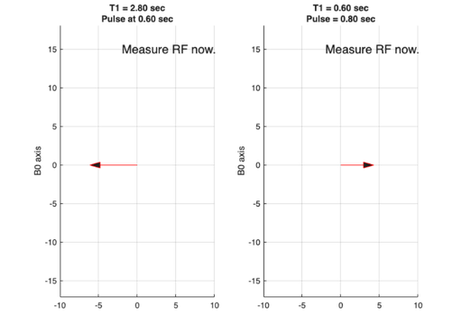

```matlab
mrvNewGraphWin;
subplot(1,2,1);
T1 = 2.8;       % 2.8 sec T1
Pulse = 0.6;    % Time of 90 deg pulse
title(sprintf('T1 = %.2f sec\nPulse at %.2f sec',T1,Pulse));
inversionRecovery(T1,Pulse);
% A faster T1 relaxation

subplot(1,2,2); cla
T1 = 0.6;        % 0.6 sec T1
Pulse = 0.8;    % Time of 90 deg pulse
title(sprintf('T1 = %.2f sec\nPulse = %.2f sec',T1,Pulse));
inversionRecovery(T1,Pulse);
```

## Question 1

If we apply a 90-degree RF pulse at the time when exactly half the signal has recovered, what do you expect the transverse magnetization to be?

Comparing the two panels, you can see that the amplitude of the transverse magnetization depends on the value of T1. The 90 deg pulse lets us measure the size of the longitudinal magnetization. The measurement takes place immediately after this 90 deg flip, so there is not much time for spin-spin dephasing. Thus, the signal we measure is mainly the size of T1. That is why inversion recovery sequences are called 'T1-weighted'.

## T2 **Spin Echo (Hahn)**

To make a T2 measurement we need only to flip the net magnetization 90 deg and then measure the signal decay as the spins dephase. The difficulty, however, is that the T2 reduction is very fast. The spin-spin dephasing occurs so quickly that it is almost impossible to obtain a T2 measurement soon enough after the 90 deg flip.

The **Hahn Spin Echo**, and another method called the **Gradient Echo**, make it possible to separate the time between the RF pulse and the measurement. Many MR pulse sequences measure these echos.

The next visualization shows two spins within a single voxel. These spins are experiencing slightly differeent local magnetic fields. Consequently, one precesses around the origin slightly faster than the other. After a little time the signals are well out of phase. Then, a 180 deg inverting pulse is introduced. This pulse rotates the spins around the horizontal axis (x-axis). Seen within the plane, this causes the two spins to reverse positions so that the leader becomes the follower. The leader is still in a higher local field, and so after a while it catches up. At that moment the spin phases come together to create an echo of the signal after the first 90 deg pulse. This echo happens at a point in time that is well separated from the inverting pulse, making it easier to measure.

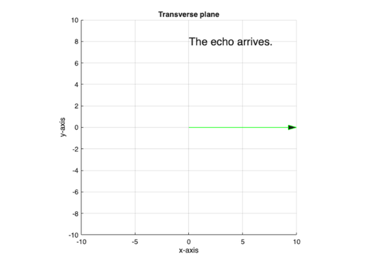

```matlab
% The time until the inverse pulse determines when the echo will occur
TE = 16;      % ms
clf;
spinEcho(TE);
```

## MR Image formation

How can we distinguish signals from different locations? This is the key step in learning how to form an image of the MR time constant's properties.

Consider a simple situation in which we have two beakers sitting next to one another on a table. **Both contain water.** Suppose the magnetic field is uniform, and suppose that we measure T1.

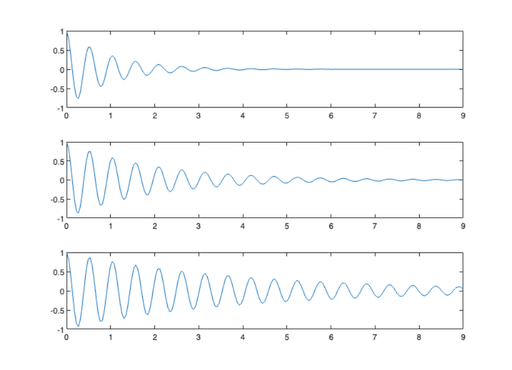

```matlab
% We are going to need these variables to develop the story.  So, run these
% few lines before continuing.
Mo = 1;                 % Net magnetization
larmorFreq(1) = 12;     % Larmor frequency in MHz/10
larmorFreq(2) = 18;     % Larmor frequency in MHz/10
T1(1) = 1.5;
T1(2) = 3;
t = (0:.005:1)*(3*max(T1)); % Time samples in secs

% The function rfSignal produces the RF signal that we will measure given a
% particular time constant and Larmor frequency.
signal = rfSignal(T1(1),Mo,t,larmorFreq(1));
figure(1); clf
subplot(1,2,1), plot(t,signal); grid on
xlabel('Time (s)'); ylabel('RF signal'); title('Beaker signal');
% The RF signal is periodic.
% We can summarize the amplitude and frequency of this signal by plotting the
% Fourier Transform amplitude spectrum. This plot measures the amplitude of each
% harmonic (temporal frequency) in the signal.

subplot(1,2,2), cla
[s,f] = powerSpecDens(signal);
plot(f,s); grid on;
xlabel('Normalized frequency'); ylabel('Normalized power'); title('Slice selection')
% Consider the signal as the relaxation constant increases.
% Notice that over the same period of time, the rfSignal has a larger amplitude
% (there is less decay).

clf;
tConstant = [1,2,4];
for ii=1:3
    subplot(3,1,ii); set(gca,'ylim',[-1,1]);
    signal = rfSignal(tConstant(ii),Mo,t,larmorFreq(1));
    plot(t,signal); hold on;
end
hold off
```

## Question 2

If you were to plot the Fourier Transform for each of the three subplots, how do you expect they would differ?

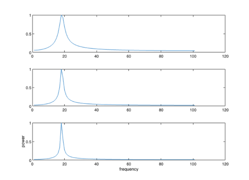

```matlab
clf;
for ii=1:3
    subplot(3,1,ii); set(gca,'ylim',[-1,1]);
    signal = rfSignal(tConstant(ii),Mo,t,larmorFreq(1));
    plot(powerSpecDens(signal));
end
xlabel('frequency'); ylabel('power')
hold off
```